# Author: Gyan Shashwat

# Project report : Development of Time series prediction model for Total Amperage Consumption of a machine.

```python
import pandas as pd
import numpy as np
import matplotlib.pyplot as plt
import seaborn as sns

import pickle

from sklearn.metrics import mean_squared_error, mean_absolute_error
from sklearn.model_selection import TimeSeriesSplit
import xgboost as xgb
from sklearn.linear_model import LinearRegression
from sklearn.linear_model import ElasticNet
from sklearn.ensemble import RandomForestRegressor
from sklearn.ensemble import ExtraTreesRegressor
from sklearn.ensemble import GradientBoostingRegressor
from sklearn.svm import SVR
from sklearn.metrics import r2_score
from sklearn.linear_model import BayesianRidge
```

```python
def mean_absolute_percentage_error(y_true, y_pred):
    """
    Calculate MAPE for given actual data (y_true) and predicted values (y_pred)
    """
    y_true = np.array(y_true)
    y_pred = np.array(y_pred)

    return np.mean(np.abs((y_true - y_pred) / y_true)) * 100
```

```python
class CFG:
    train_CV_model = True
    train_model = True
    train_complete_model = True
    plot_graphs = True
```

```python
df = pd.read_excel("data.xlsx")
df.info()
```

```
<class 'pandas.core.frame.DataFrame'>
RangeIndex: 10000 entries, 0 to 9999
Data columns (total 10 columns):
 #   Column                  Non-Null Count  Dtype
---  ------                  --------------  -----
 0   time                    10000 non-null  datetime64[ns]
 1   MonthName               10000 non-null  object
 2   WeekDay                 10000 non-null  object
 3   WeekNumber              10000 non-null  int64
 4   phase_1_current_amp     10000 non-null  float64
 5   phase_2_current_amp     10000 non-null  float64
 6   phase_3_current_amp     10000 non-null  float64
 7   TotalCurrentAmperage    10000 non-null  float64
 8   AverageCurrentAmperage  10000 non-null  float64
 9   PowerStatus             10000 non-null  object
dtypes: datetime64[ns](1), float64(5), int64(1), object(3)
memory usage: 781.4+ KB
```

```python
df = df.set_index('time')
df.index = pd.to_datetime(df.index)
display(df)
```

| time | MonthName | WeekDay | WeekNumber | phase_1_current_amp | phase_2_current_amp | phase_3_current_amp | TotalCurrentAmperage | AverageCurrentAmperage | PowerStatus |
| --- | --- | --- | --- | --- | --- | --- | --- | --- | --- |
| 2023-11-17 07:35:52 | November | Friday | 46 | 10.281491 | 11.570706 | 10.984953 | 32.837150 | 10.945717 | On |
| 2023-11-17 07:36:22 | November | Friday | 46 | 10.506440 | 11.650215 | 10.933455 | 33.090110 | 11.030037 | On |
| 2023-11-17 07:50:12 | November | Friday | 46 | 10.573857 | 12.088927 | 10.978826 | 33.641610 | 11.213870 | On |
| 2023-11-17 07:50:42 | November | Friday | 46 | 10.298803 | 11.997374 | 10.799131 | 33.095308 | 11.031769 | On |
| 2023-11-17 07:51:12 | November | Friday | 46 | 10.248630 | 11.768479 | 10.787249 | 32.804358 | 10.934786 | On |
| ... | ... | ... | ... | ... | ... | ... | ... | ... | ... |
| 2023-11-21 16:44:36 | November | Tuesday | 47 | 1.032101 | 1.207038 | 1.136952 | 3.376092 | 1.125364 | Off |
| 2023-11-21 16:45:01 | November | Tuesday | 47 | 1.033842 | 1.200865 | 1.135421 | 3.370128 | 1.123376 | Off |
| 2023-11-21 16:45:26 | November | Tuesday | 47 | 1.026253 | 1.204462 | 1.132380 | 3.363096 | 1.121032 | Off |
| 2023-11-21 16:45:50 | November | Tuesday | 47 | 1.033262 | 1.201701 | 1.136604 | 3.371567 | 1.123856 | Off |
| 2023-11-21 16:46:13 | November | Tuesday | 47 | 1.030732 | 1.204300 | 1.139366 | 3.374398 | 1.124799 | Off |

10000 rows × 9 columns

```python
df.nunique()
```

```
MonthName                    1
WeekDay                      5
WeekNumber                   2
phase_1_current_amp       5173
phase_2_current_amp       4476
phase_3_current_amp       5152
TotalCurrentAmperage      9073
AverageCurrentAmperage    9073
PowerStatus                  2
dtype: int64
```

### The data is only for one month, it shows less variance in a time series data

# Data Visulization and EDA

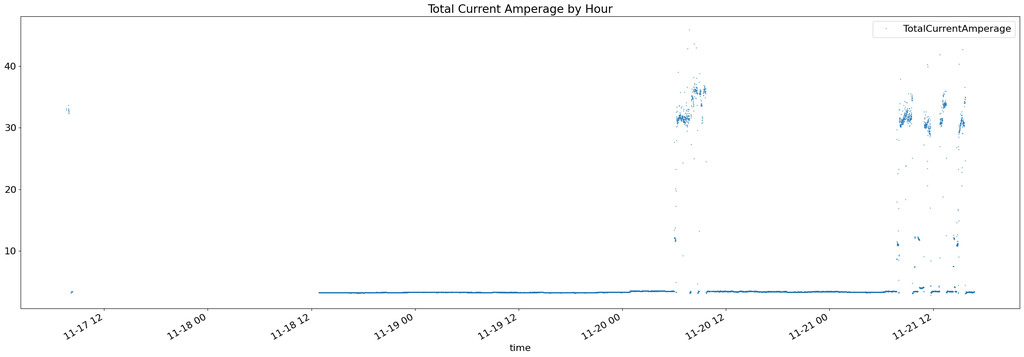

```python
color_pal = sns.color_palette()
#ms = marker size
df.plot(y='TotalCurrentAmperage', style='.', figsize=(30,10), color=color_pal[0],
        title='Total Current Amperage by Hour', ms=1)
plt.show()
```

### This plot elaborates the value of TotalCurrentAmperage are highly unbalanced with respect to date and have less varince.

```python
df.TotalCurrentAmperage.describe()
```

```
count    10000.000000
mean         6.092420
std          8.362587
min          2.796372
25%          3.265642
50%          3.308025
75%          3.430914
max         45.887653
Name: TotalCurrentAmperage, dtype: float64
```

### The stastical discription of the response variable shows even third quantile values (75 percent of values are less than 3.43), therefore 45 can be considered as outlier but the above plot shows a lot of scatters which is more than considers to be an outlier, thereffore more analysis is required.

```python
df.select_dtypes(['float64','int64']).corr()
```

|  | WeekNumber | phase_1_current_amp | phase_2_current_amp | phase_3_current_amp | TotalCurrentAmperage | AverageCurrentAmperage |
| --- | --- | --- | --- | --- | --- | --- |
| WeekNumber | 1.000000 | 0.128157 | 0.126688 | 0.127739 | 0.127557 | 0.127557 |
| phase_1_current_amp | 0.128157 | 1.000000 | 0.998758 | 0.997536 | 0.999262 | 0.999262 |
| phase_2_current_amp | 0.126688 | 0.998758 | 1.000000 | 0.998810 | 0.999754 | 0.999754 |
| phase_3_current_amp | 0.127739 | 0.997536 | 0.998810 | 1.000000 | 0.999349 | 0.999349 |
| TotalCurrentAmperage | 0.127557 | 0.999262 | 0.999754 | 0.999349 | 1.000000 | 1.000000 |
| AverageCurrentAmperage | 0.127557 | 0.999262 | 0.999754 | 0.999349 | 1.000000 | 1.000000 |

- The correlation within phase1, phase2, phase3 and Average Current Amperage is very high, therefore we can use any one of them.
- All of these X variables are highly correlated with the response variable (TotalCurrentAmperage), but I am assuming to use the time series model in real time the user will only provide date range and power status of the machine on respective dates.

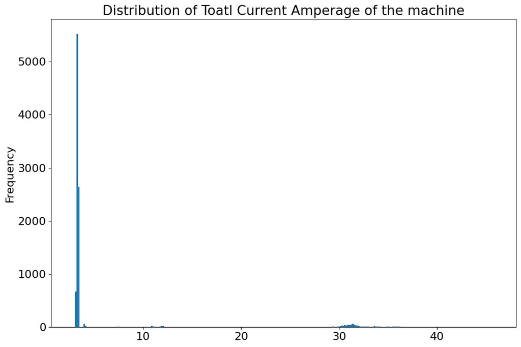

```python
if CFG.plot_graphs:
    df['TotalCurrentAmperage'].plot(kind='hist', bins=300, title='Distribution of Toatl Current Amperage of the machine')
    plt.show()
```

- This distribution plot shows an exponetial plot, and skewed. This will require transformation for getting a uniform distribution

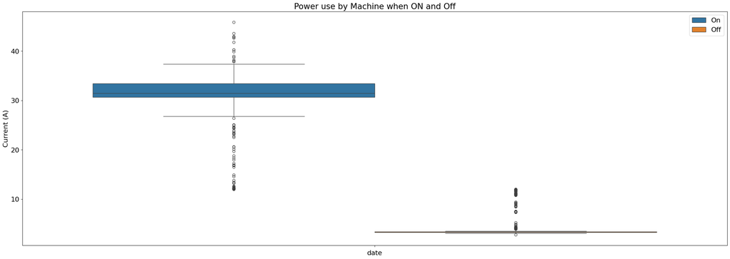

```python
if CFG.plot_graphs:
    fig, ax = plt.subplots(figsize=(30,10))
    sns.boxplot(data=df, y='TotalCurrentAmperage', hue='PowerStatus', ax=ax, linewidth=1)
    plt.title("Power use by Machine when ON and Off")
    plt.xlabel("date")
    plt.ylabel("Current (A)")
    ax.legend(bbox_to_anchor=(1, 1))
    plt.show()
```

### This plot concludes that power status is one of the most important factor for the prediction of Amperage usage by the machine. The distinctive pattern in the data points based of power status of the machine will help the model to predict closer to the actual values.

### This also help us to undestand the 25 percent of data points above 3.4 is also significant and can not be considered as outliers.

# Feature Engineering

### Creating Power status code

Transforming Power status into numeric value as it is a significant variable (factor) in predicting ampere usage and shows a distinctive data pattern.

- Off (0)
- On (1)

```python
df['PowerStatusCode'] = 0
df['PowerStatusCode'].loc[df['PowerStatus']=='On']=1
```

Checking the correlation for power status code with the response variable (TotalAmpereUsage)

```python
df.select_dtypes(['float64','int64']).corr()
```

|  | WeekNumber | phase_1_current_amp | phase_2_current_amp | phase_3_current_amp | TotalCurrentAmperage | AverageCurrentAmperage | PowerStatusCode |
| --- | --- | --- | --- | --- | --- | --- | --- |
| WeekNumber | 1.000000 | 0.128157 | 0.126688 | 0.127739 | 0.127557 | 0.127557 | 0.122366 |
| phase_1_current_amp | 0.128157 | 1.000000 | 0.998758 | 0.997536 | 0.999262 | 0.999262 | 0.979093 |
| phase_2_current_amp | 0.126688 | 0.998758 | 1.000000 | 0.998810 | 0.999754 | 0.999754 | 0.980278 |
| phase_3_current_amp | 0.127739 | 0.997536 | 0.998810 | 1.000000 | 0.999349 | 0.999349 | 0.979866 |
| TotalCurrentAmperage | 0.127557 | 0.999262 | 0.999754 | 0.999349 | 1.000000 | 1.000000 | 0.980299 |
| AverageCurrentAmperage | 0.127557 | 0.999262 | 0.999754 | 0.999349 | 1.000000 | 1.000000 | 0.980299 |
| PowerStatusCode | 0.122366 | 0.979093 | 0.980278 | 0.979866 | 0.980299 | 0.980299 | 1.000000 |

Power status code is higly correlated with the response variable. Therefore it is siginificant categorical variable to predict the usage.

### Creating time series feature

```python
def create_time_series_features(df):
    """
    Creates time series based feature based on datetime index
    """
    df = df.copy()
    df['PowerStatusCode'] = df.PowerStatusCode
    df['date'] = df.index
    if df['WeekNumber'].empty:
      print('in')
      df['WeekNumber'] = df['WeekNumber']
    else:
      print('out')
      df['WeekNumber'] = df['date'].dt.isocalendar().week
    df['hour'] = df.index.hour
    df['dayofweek'] = df.index.dayofweek
    df['year'] = df.index.year
    df['dayofyear'] = df.index.dayofyear
    df['quarter'] = df.index.quarter
    df['dayofmonth'] = df['date'].dt.day
    df['date_offset'] = (df.date.dt.month*100 + df.date.dt.day - 320)%1300
    df['season'] = pd.cut(df['date_offset'], [-1, 300, 602, 900, 1301],
                         labels=['Spring', 'Summer', 'Fall', 'Winter'])
    return df
```

```python
df = create_time_series_features(df)
```

```
out
```

```python
df.info()
```

```
<class 'pandas.core.frame.DataFrame'>
DatetimeIndex: 10000 entries, 2023-11-17 07:35:52 to 2023-11-21 16:46:13
Data columns (total 19 columns):
 #   Column                  Non-Null Count  Dtype
---  ------                  --------------  -----
 0   MonthName               10000 non-null  object
 1   WeekDay                 10000 non-null  object
 2   WeekNumber              10000 non-null  UInt32
 3   phase_1_current_amp     10000 non-null  float64
 4   phase_2_current_amp     10000 non-null  float64
 5   phase_3_current_amp     10000 non-null  float64
 6   TotalCurrentAmperage    10000 non-null  float64
 7   AverageCurrentAmperage  10000 non-null  float64
 8   PowerStatus             10000 non-null  object
 9   PowerStatusCode         10000 non-null  int64
 10  date                    10000 non-null  datetime64[ns]
 11  hour                    10000 non-null  int32
 12  dayofweek               10000 non-null  int32
 13  year                    10000 non-null  int32
 14  dayofyear               10000 non-null  int32
 15  quarter                 10000 non-null  int32
 16  dayofmonth              10000 non-null  int32
 17  date_offset             10000 non-null  int32
 18  season                  10000 non-null  category
dtypes: UInt32(1), category(1), datetime64[ns](1), float64(5), int32(7), int64(1), object(3)
memory usage: 1.2+ MB
```

```python
df.select_dtypes(['float64','int32','UInt32']).corr()
```

|  | WeekNumber | phase_1_current_amp | phase_2_current_amp | phase_3_current_amp | TotalCurrentAmperage | AverageCurrentAmperage | hour | dayofweek | year | dayofyear | quarter | dayofmonth | date_offset |
| --- | --- | --- | --- | --- | --- | --- | --- | --- | --- | --- | --- | --- | --- |
| WeekNumber | 1.000000 | 0.296621 | 0.291722 | 0.293026 | 0.293816 | 0.293816 | -0.239738 | -0.982779 | NaN | 0.873039 | NaN | 0.873039 | 0.873039 |
| phase_1_current_amp | 0.296621 | 1.000000 | 0.998758 | 0.997536 | 0.999262 | 0.999262 | -0.106079 | -0.273269 | NaN | 0.307106 | NaN | 0.307106 | 0.307106 |
| phase_2_current_amp | 0.291722 | 0.998758 | 1.000000 | 0.998810 | 0.999754 | 0.999754 | -0.102944 | -0.267572 | NaN | 0.305159 | NaN | 0.305159 | 0.305159 |
| phase_3_current_amp | 0.293026 | 0.997536 | 0.998810 | 1.000000 | 0.999349 | 0.999349 | -0.103170 | -0.268739 | NaN | 0.306598 | NaN | 0.306598 | 0.306598 |
| TotalCurrentAmperage | 0.293816 | 0.999262 | 0.999754 | 0.999349 | 1.000000 | 1.000000 | -0.104036 | -0.269852 | NaN | 0.306400 | NaN | 0.306400 | 0.306400 |
| AverageCurrentAmperage | 0.293816 | 0.999262 | 0.999754 | 0.999349 | 1.000000 | 1.000000 | -0.104036 | -0.269852 | NaN | 0.306400 | NaN | 0.306400 | 0.306400 |
| hour | -0.239738 | -0.106079 | -0.102944 | -0.103170 | -0.104036 | -0.104036 | 1.000000 | 0.171057 | NaN | -0.379655 | NaN | -0.379655 | -0.379655 |
| dayofweek | -0.982779 | -0.273269 | -0.267572 | -0.268739 | -0.269852 | -0.269852 | 0.171057 | 1.000000 | NaN | -0.767892 | NaN | -0.767892 | -0.767892 |
| year | NaN | NaN | NaN | NaN | NaN | NaN | NaN | NaN | NaN | NaN | NaN | NaN | NaN |
| dayofyear | 0.873039 | 0.307106 | 0.305159 | 0.306598 | 0.306400 | 0.306400 | -0.379655 | -0.767892 | NaN | 1.000000 | NaN | 1.000000 | 1.000000 |
| quarter | NaN | NaN | NaN | NaN | NaN | NaN | NaN | NaN | NaN | NaN | NaN | NaN | NaN |
| dayofmonth | 0.873039 | 0.307106 | 0.305159 | 0.306598 | 0.306400 | 0.306400 | -0.379655 | -0.767892 | NaN | 1.000000 | NaN | 1.000000 | 1.000000 |
| date_offset | 0.873039 | 0.307106 | 0.305159 | 0.306598 | 0.306400 | 0.306400 | -0.379655 | -0.767892 | NaN | 1.000000 | NaN | 1.000000 | 1.000000 |

```python
df.WeekNumber.unique()
```

```
<IntegerArray>
[46, 47]
Length: 2, dtype: UInt32
```

### Significant variables to predict the Total current usage.

- The Week Number, day of week, day of year, day of month and day_offset has more than 0.20 correlation with the response variable. Though the day of year, day of month and day_offset has same correlation, therefore we can take any one of them as a factor.
- The other variables like phase1, phase2, phase3 and AverageCurrentAmperage are highle correlated but I am assuming the prediction of Total Amperage usage will be based on only dates and power status of the machine in real time as the Total Amperage Usage is the sum of phase1, phase2, phase3. Therefore, I will discard them as x variables for the prediction.

### Distribution transformation of the response variable

- Earlier in the data visualisation we saw the distribution of the TotalCurrentUsage that the distribution is skewed and exponetial in nature. Therefore, we will apply log transform of the distribution to be more uniform and then we will check the correlation of x variable with the response variable.

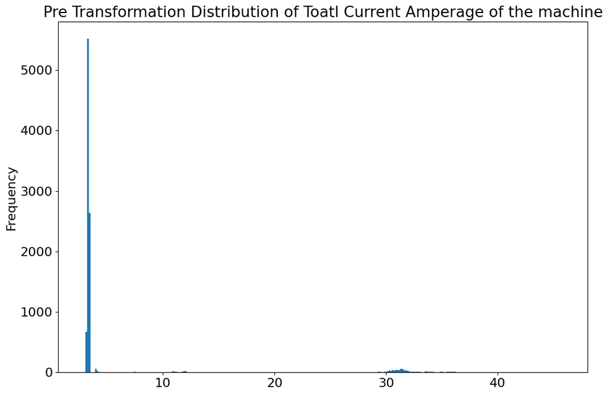

```python
if CFG.plot_graphs:
    df['TotalCurrentAmperage'].plot(kind='hist', bins=300, title='Pre Transformation Distribution of Toatl Current Amperage of the machine')
    plt.show()
```

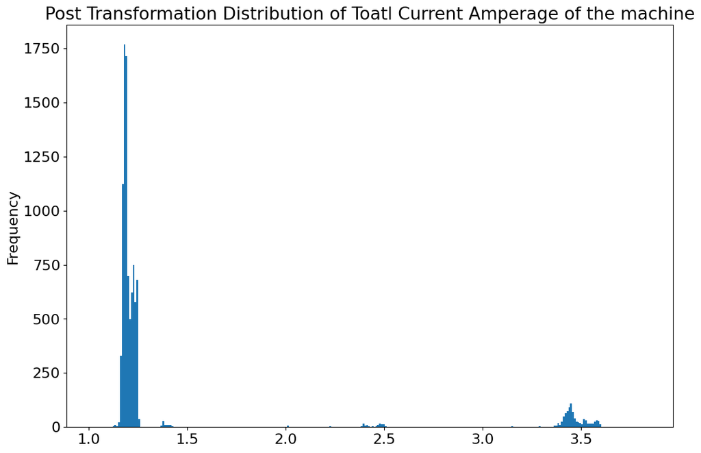

```python
if CFG.plot_graphs:
    np.log(df['TotalCurrentAmperage']).plot(kind='hist', bins=300, title='Post Transformation Distribution of Toatl Current Amperage of the machine')
    plt.show()
```

- The distribution plot looks more uniform. Let's check the correlation of log transformed value of response variable with x variables

### Post Feature EDA and Initial ML analysis

```python
df['TransformedTotalCurrentAmperage'] = np.log(df['TotalCurrentAmperage'])
df.select_dtypes(['float64','int32','UInt32']).corr()
```

|  | WeekNumber | phase_1_current_amp | phase_2_current_amp | phase_3_current_amp | TotalCurrentAmperage | AverageCurrentAmperage | hour | dayofweek | year | dayofyear | quarter | dayofmonth | date_offset | TransformedTotalCurrentAmperage |
| --- | --- | --- | --- | --- | --- | --- | --- | --- | --- | --- | --- | --- | --- | --- |
| WeekNumber | 1.000000 | 0.296621 | 0.291722 | 0.293026 | 0.293816 | 0.293816 | -0.239738 | -0.982779 | NaN | 0.873039 | NaN | 0.873039 | 0.873039 | 0.322566 |
| phase_1_current_amp | 0.296621 | 1.000000 | 0.998758 | 0.997536 | 0.999262 | 0.999262 | -0.106079 | -0.273269 | NaN | 0.307106 | NaN | 0.307106 | 0.307106 | 0.990910 |
| phase_2_current_amp | 0.291722 | 0.998758 | 1.000000 | 0.998810 | 0.999754 | 0.999754 | -0.102944 | -0.267572 | NaN | 0.305159 | NaN | 0.305159 | 0.305159 | 0.992978 |
| phase_3_current_amp | 0.293026 | 0.997536 | 0.998810 | 1.000000 | 0.999349 | 0.999349 | -0.103170 | -0.268739 | NaN | 0.306598 | NaN | 0.306598 | 0.306598 | 0.991191 |
| TotalCurrentAmperage | 0.293816 | 0.999262 | 0.999754 | 0.999349 | 1.000000 | 1.000000 | -0.104036 | -0.269852 | NaN | 0.306400 | NaN | 0.306400 | 0.306400 | 0.992275 |
| AverageCurrentAmperage | 0.293816 | 0.999262 | 0.999754 | 0.999349 | 1.000000 | 1.000000 | -0.104036 | -0.269852 | NaN | 0.306400 | NaN | 0.306400 | 0.306400 | 0.992275 |
| hour | -0.239738 | -0.106079 | -0.102944 | -0.103170 | -0.104036 | -0.104036 | 1.000000 | 0.171057 | NaN | -0.379655 | NaN | -0.379655 | -0.379655 | -0.112538 |
| dayofweek | -0.982779 | -0.273269 | -0.267572 | -0.268739 | -0.269852 | -0.269852 | 0.171057 | 1.000000 | NaN | -0.767892 | NaN | -0.767892 | -0.767892 | -0.295534 |
| year | NaN | NaN | NaN | NaN | NaN | NaN | NaN | NaN | NaN | NaN | NaN | NaN | NaN | NaN |
| dayofyear | 0.873039 | 0.307106 | 0.305159 | 0.306598 | 0.306400 | 0.306400 | -0.379655 | -0.767892 | NaN | 1.000000 | NaN | 1.000000 | 1.000000 | 0.338292 |
| quarter | NaN | NaN | NaN | NaN | NaN | NaN | NaN | NaN | NaN | NaN | NaN | NaN | NaN | NaN |
| dayofmonth | 0.873039 | 0.307106 | 0.305159 | 0.306598 | 0.306400 | 0.306400 | -0.379655 | -0.767892 | NaN | 1.000000 | NaN | 1.000000 | 1.000000 | 0.338292 |
| date_offset | 0.873039 | 0.307106 | 0.305159 | 0.306598 | 0.306400 | 0.306400 | -0.379655 | -0.767892 | NaN | 1.000000 | NaN | 1.000000 | 1.000000 | 0.338292 |
| TransformedTotalCurrentAmperage | 0.322566 | 0.990910 | 0.992978 | 0.991191 | 0.992275 | 0.992275 | -0.112538 | -0.295534 | NaN | 0.338292 | NaN | 0.338292 | 0.338292 | 1.000000 |

- The correlation with the transformed value of response variable and x variables is higher than the non transformed response variable. We will use a initial ML model to determine the prediction error for both the response variable.

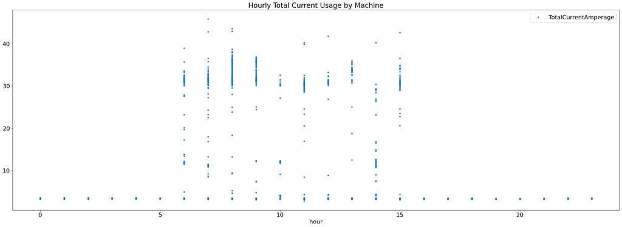

```python
if CFG.plot_graphs:
    df.plot(
        y='TotalCurrentAmperage',x='hour', style='.', figsize=(30,10), color=color_pal[0],
        title='Hourly Total Current Usage by Machine')
    plt.show()
```

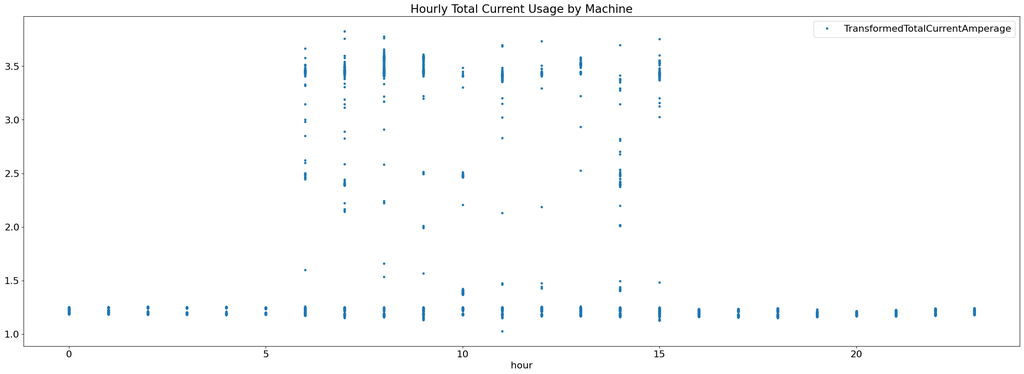

```python
if CFG.plot_graphs:
    df.plot(
        y='TransformedTotalCurrentAmperage',x='hour', style='.', figsize=(30,10), color=color_pal[0],
        title='Hourly Total Current Usage by Machine')
    plt.show()
```

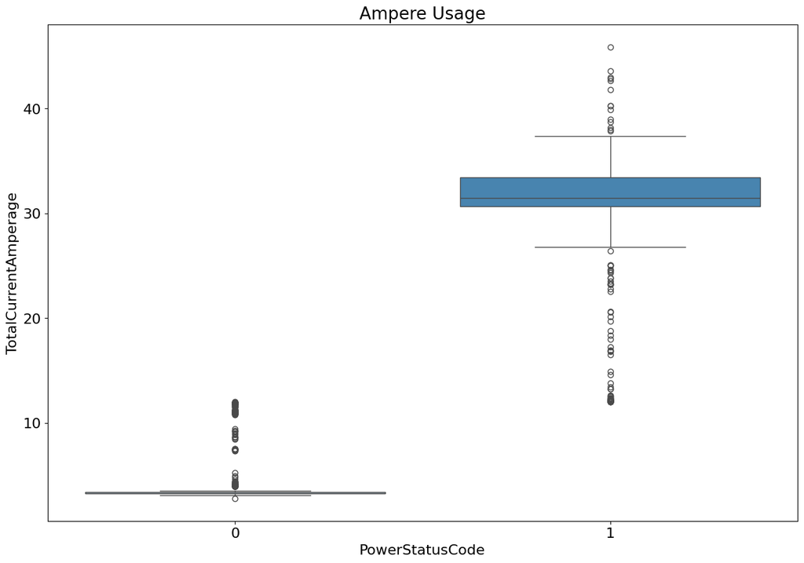

```python
if CFG.plot_graphs:
    fig, ax = plt.subplots(figsize=(15,10))
    sns.boxplot(data=df, x='PowerStatusCode', y='TotalCurrentAmperage', palette='Blues')
    plt.title("Ampere Usage")
    plt.show()
```

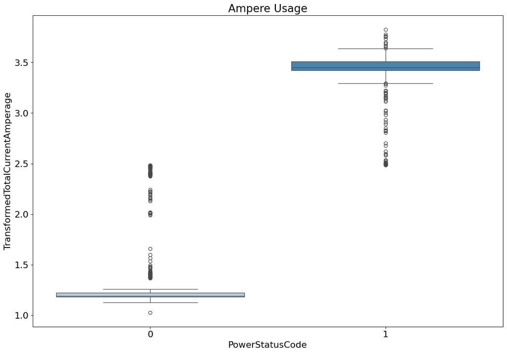

```python
if CFG.plot_graphs:
    fig, ax = plt.subplots(figsize=(15,10))
    sns.boxplot(data=df, x='PowerStatusCode', y='TransformedTotalCurrentAmperage', palette='Blues')
    plt.title("Ampere Usage")
    plt.show()
```

- The above plots and correlation table shows change in the correlation value in distribution of the data points from pre and post transformed data.
- Let's check what diffrence it brings in prediction by an initial ML model on using both pre and post transformed response variable.

### Linear regression model.

- Taking the significant variable and divide them in train and test data.

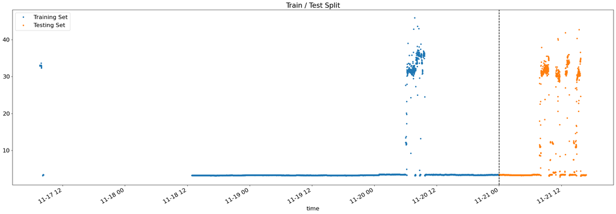

```python
#Pre transformation data
train = df.loc[df.index < '11-21-2023'].copy()
test = df.loc[df.index >= '11-21-2023'].copy()

fig, ax = plt.subplots(figsize=(30,10))
train.plot(y = 'TotalCurrentAmperage', style='.', ax=ax, label='Training Set')
test.plot(y = 'TotalCurrentAmperage', style='.', ax=ax, label='Test Set')
ax.legend(["Training Set", "Testing Set"])
ax.axvline(test.index.min(), color='black', ls='--')
plt.title("Train / Test Split")
plt.show()
```

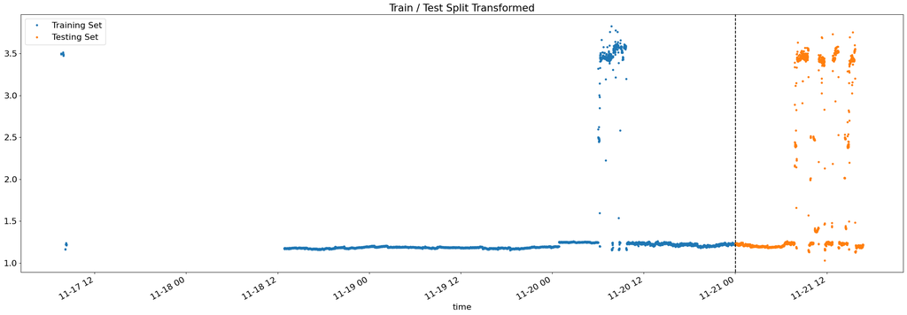

```python
#Post transformation data
transform_train = df.loc[df.index < '11-21-2023'].copy()
transform_test = df.loc[df.index >= '11-21-2023'].copy()

fig, ax = plt.subplots(figsize=(30,10))
transform_train.plot(y = 'TransformedTotalCurrentAmperage', style='.', ax=ax, label='Training Set')
transform_test.plot(y = 'TransformedTotalCurrentAmperage', style='.', ax=ax, label='Test Set')
ax.legend(["Training Set", "Testing Set"])
ax.axvline(transform_test.index.min(), color='black', ls='--')
plt.title("Train / Test Split Transformed")
plt.show()
```

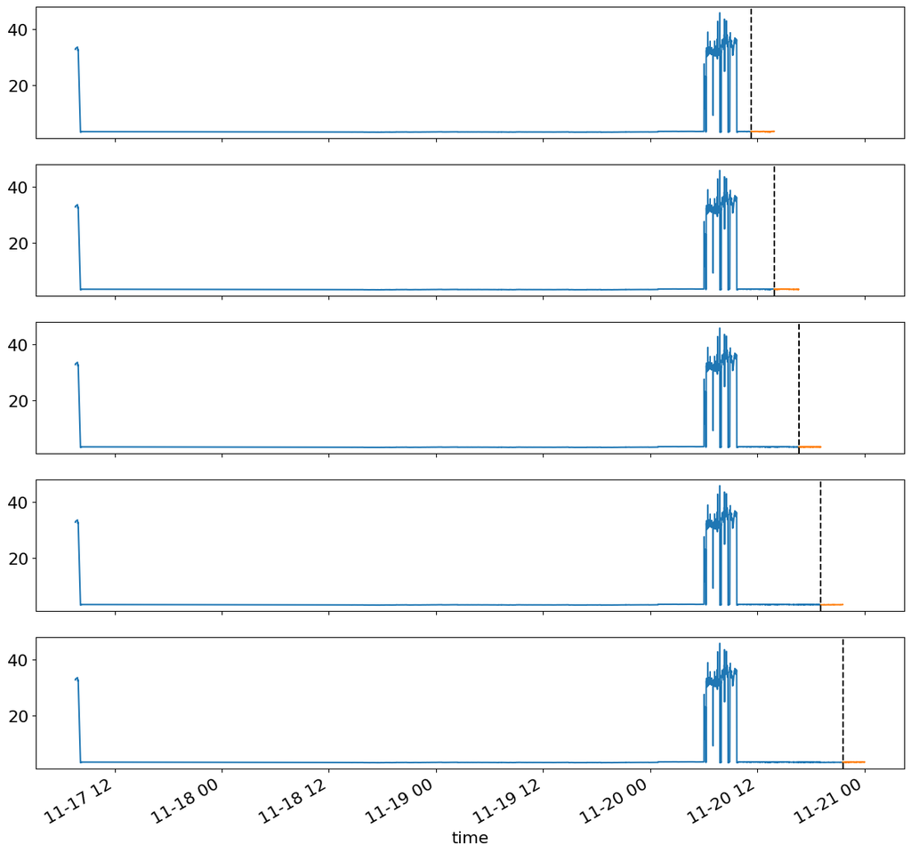

```python
#Pre transformation data
 if CFG.plot_graphs:
    #we are creating a test and eval set generator
    #which can generate 5 test and eval sets when we iterate over it
    #here test size is 1 year and gap between test and train set is 1 day
    tss = TimeSeriesSplit(n_splits=5, test_size=365, gap=1)
    train = train.sort_index()

    fig, axs = plt.subplots(5, 1, figsize=(15,15), sharex=True)

    fold=0
    for train_idx, eval_idx in tss.split(train):
        train_set=train.iloc[train_idx]
        eval_set=train.iloc[eval_idx]
        train_set['TotalCurrentAmperage'].plot(ax=axs[fold], label="Training Set")
        eval_set['TotalCurrentAmperage'].plot(ax=axs[fold], label='Test Set')
        axs[fold].axvline(eval_set.index.min(), color='black', ls='--')
        fold += 1
    plt.show()
```

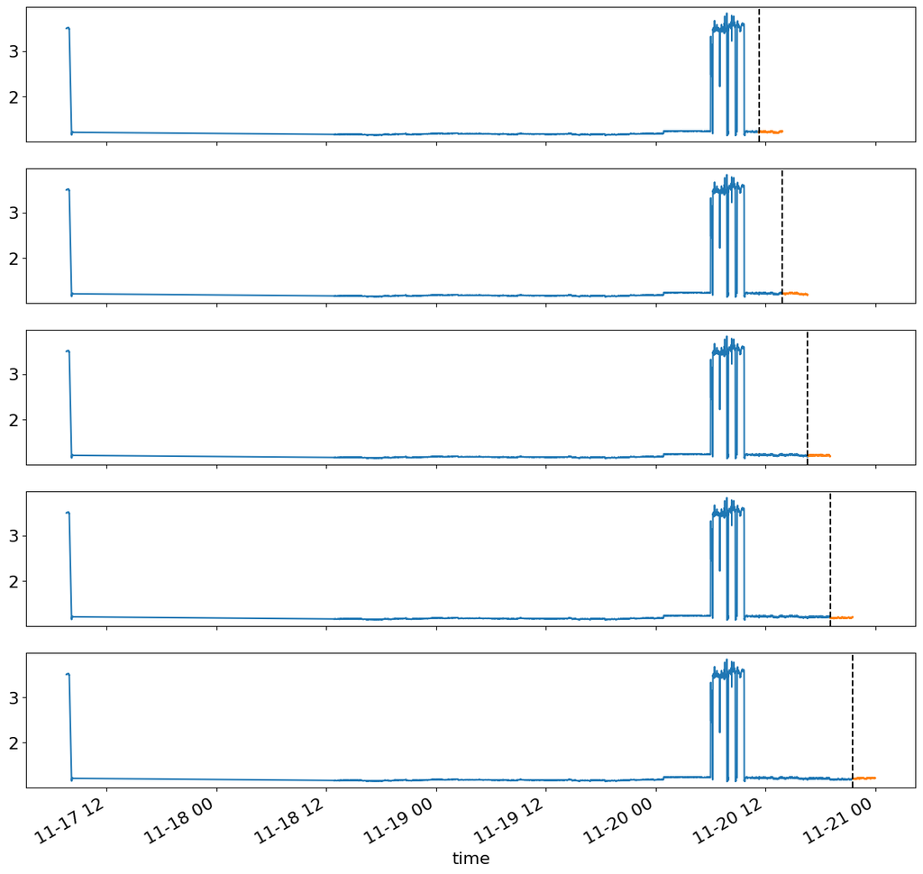

```python
#Post transformation data
 if CFG.plot_graphs:
    #we are creating a test and eval set generator
    #which can generate 5 test and eval sets when we iterate over it
    #here test size is 1 year and gap between test and train set is 1 day
    tss = TimeSeriesSplit(n_splits=5, test_size=365, gap=1)
    train = train.sort_index()

    fig, axs = plt.subplots(5, 1, figsize=(15,15), sharex=True)

    fold=0
    for train_idx, eval_idx in tss.split(train):
        train_set=transform_train.iloc[train_idx]
        eval_set=transform_train.iloc[eval_idx]
        train_set['TransformedTotalCurrentAmperage'].plot(ax=axs[fold], label="Training Set")
        eval_set['TransformedTotalCurrentAmperage'].plot(ax=axs[fold], label='Test Set')
        axs[fold].axvline(eval_set.index.min(), color='black', ls='--')
        fold += 1
    plt.show()
```

```python
features_xgb_reg = ['WeekNumber', 'dayofweek',
       'dayofyear','PowerStatusCode']
features_xgb_reg_hour = ['WeekNumber','hour', 'dayofweek',
       'dayofyear','PowerStatusCode']

target = 'TotalCurrentAmperage'
transformed_target = 'TransformedTotalCurrentAmperage'
```

```python
X_train_hour = train[features_xgb_reg_hour]
y_train_hour = train[target]
```

```python
lin_reg = LinearRegression()
lin_reg.fit(X_train_hour, y_train_hour)
```

```
LinearRegression()
```

```python
y_train_pred_hour = pd.Series(lin_reg.predict(X_train_hour), index=X_train_hour.index)
```

```python
X_test_hour = test[features_xgb_reg_hour]
y_test_hour = test[target]
y_test_hour_pred = pd.Series(lin_reg.predict(X_test_hour), index=X_test_hour.index)
```

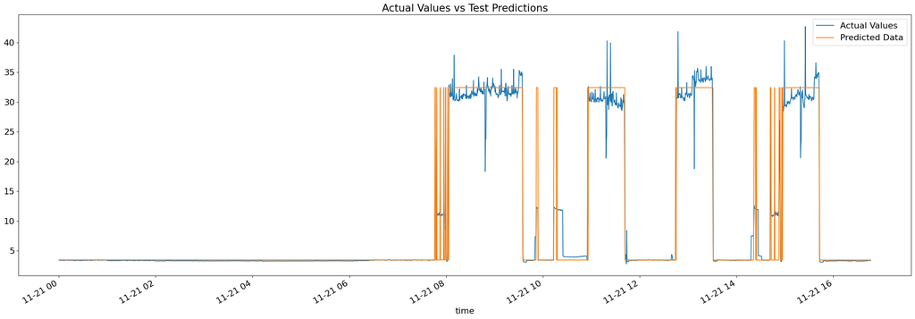

```python
ax = test[['TotalCurrentAmperage']].plot(figsize=(30, 10))
y_test_hour_pred.plot(ax=ax)
plt.legend(['Actual Values', 'Predicted Data'])
plt.title("Actual Values vs Test Predictions")
plt.show()
```

```python
score_train = mean_absolute_percentage_error(train['TotalCurrentAmperage'], y_train_pred_hour)
print(f'MAPE Score on test set: {score_train:0.2f}')
```

```
MAPE Score on test set: 1.64
```

```python
score_test = mean_absolute_percentage_error(test['TotalCurrentAmperage'], y_test_hour_pred)
print(f'MAPE Score on test set: {score_test:0.2f}')
```

```
MAPE Score on test set: 8.55
```

```python
model_name = []
training_scores = []
testing_scores = []
model_name.append("Linear Regression Model with hour x variable")
training_scores.append(score_train)
testing_scores.append(score_test)
```

```python
X_train = train[features_xgb_reg]
y_train = train[target]
```

```python
lin_reg = LinearRegression()
lin_reg.fit(X_train, y_train)
```

```
LinearRegression()
```

```python
y_train_pred = pd.Series(lin_reg.predict(X_train), index=X_train.index)
```

```python
X_test = test[features_xgb_reg]
y_test = test[target]
y_test_pred = pd.Series(lin_reg.predict(X_test), index=X_test.index)
```

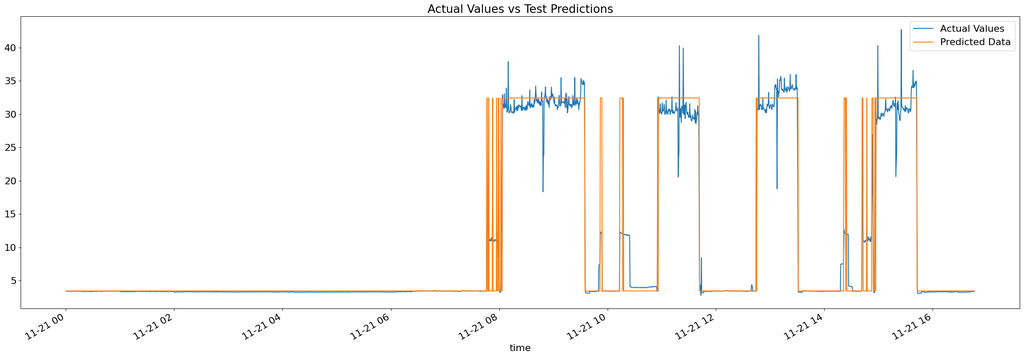

```python
ax = test[['TotalCurrentAmperage']].plot(figsize=(30, 10))
y_test_pred.plot(ax=ax)
plt.legend(['Actual Values', 'Predicted Data'])
plt.title("Actual Values vs Test Predictions")
plt.show()
```

```python
score_train = mean_absolute_percentage_error(train['TotalCurrentAmperage'], y_train_hour)
print(f'MAPE Score on train set: {score_train:0.2f}')
```

```
MAPE Score on train set: 0.00
```

```python
score_test = mean_absolute_percentage_error(test['TotalCurrentAmperage'], y_test_pred)
print(f'MAPE Score on test set: {score_test:0.2f}')
```

```
MAPE Score on test set: 8.31
```

```python
model_name.append("Linear Regression Model without hour as x variable")
training_scores.append(score_train)
testing_scores.append(score_test)
```

### With transformed response variable.

```python
X_train_hour = train[features_xgb_reg_hour]
y_train_hour_transformed = train[transformed_target]
```

```python
lin_reg = LinearRegression()
lin_reg.fit(X_train_hour, y_train_hour_transformed)
```

```
LinearRegression()
```

```python
y_train_pred_hour = pd.Series(lin_reg.predict(X_train_hour), index=X_train_hour.index)
```

```python
X_test_hour = test[features_xgb_reg_hour]
y_test_hour_transformed = test[transformed_target]
y_test_hour_pred = pd.Series(lin_reg.predict(X_test_hour), index=X_test_hour.index)
```

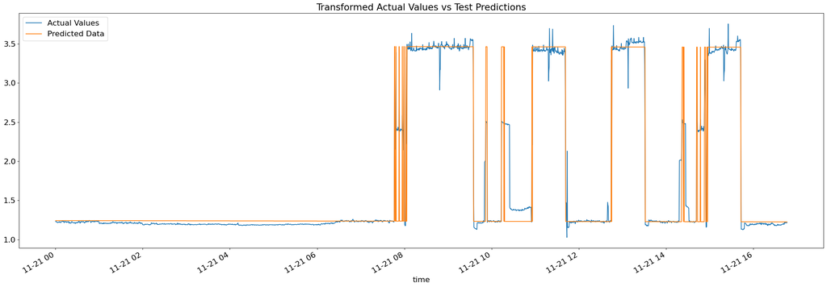

```python
ax = test[['TransformedTotalCurrentAmperage']].plot(figsize=(30, 10))
y_test_hour_pred.plot(ax=ax)
plt.legend(['Actual Values', 'Predicted Data'])
plt.title("Transformed Actual Values vs Test Predictions")
plt.show()
```

```python
score_train = mean_absolute_percentage_error(train['TransformedTotalCurrentAmperage'], y_train_pred_hour)
print(f'MAPE Score on train set: {score_train:0.2f}')
```

```
MAPE Score on train set: 0.95
```

```python
score_test = mean_absolute_percentage_error(test['TransformedTotalCurrentAmperage'], y_test_hour_pred)
print(f'MAPE Score on test set: {score_test:0.2f}')
```

```
MAPE Score on test set: 4.64
```

```python
model_name.append("Transformed Linear Regression Model with hour x variable")
training_scores.append(score_train)
testing_scores.append(score_test)
```

```python
X_train = train[features_xgb_reg]
y_train_transformed = train[transformed_target]
```

```python
lin_reg = LinearRegression()
lin_reg.fit(X_train, y_train_transformed)
```

```
LinearRegression()
```

```python
y_train_pred = pd.Series(lin_reg.predict(X_train), index=X_train.index)
```

```python
X_test = test[features_xgb_reg]
y_test = test[transformed_target]
y_test_pred = pd.Series(lin_reg.predict(X_test), index=X_test.index)
```

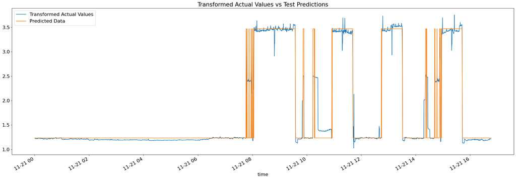

```python
ax = test[['TransformedTotalCurrentAmperage']].plot(figsize=(30, 10))
y_test_pred.plot(ax=ax)
plt.legend(['Transformed Actual Values', 'Predicted Data'])
plt.title("Transformed Actual Values vs Test Predictions")
plt.show()
```

```python
score_train = mean_absolute_percentage_error(train['TransformedTotalCurrentAmperage'], y_train_hour)
print(f'MAPE Score on train set: {score_train:0.2f}')
```

```
MAPE Score on train set: 209.26
```

```python
score_test = mean_absolute_percentage_error(test['TransformedTotalCurrentAmperage'], y_test_pred)
print(f'MAPE Score on test set: {score_test:0.2f}')
```

```
MAPE Score on test set: 4.55
```

```python
model_name.append("Transformed Linear Regression Model without hour as x variable")
training_scores.append(score_train)
testing_scores.append(score_test)
```

### Selecting most significant x and response variable

```python
model_scores = pd.DataFrame({'Model Names' : model_name, 'Training Scores' : training_scores, 'Testing Scores' : testing_scores})
model_scores = model_scores.set_index('Model Names')
model_scores
```

| Model Names | Training Scores | Testing Scores |
| --- | --- | --- |
| Linear Regression Model with hour x variable | 1.636133 | 8.545395 |
| Linear Regression Model without hour as x variable | 0.000000 | 8.307741 |
| Transformed Linear Regression Model with hour x variable | 0.948260 | 4.639980 |
| Transformed Linear Regression Model without hour as x variable | 209.260015 | 4.547847 |

# Model Selection

```python
# Distributions
import scipy
# Evaluate several ml models by training on training set and testing on testing set
def evaluate(X_train, X_test, y_train, y_test):
    # Names of models
    model_name_list = ['Linear Regression', 'ElasticNet Regression',
                      'Random Forest', 'Extra Trees', 'SVM',
                       'Gradient Boosted', 'XGBoost','Baseline']
    #X_train = X_train.drop(columns='Grade')
    #X_test = X_test.drop(columns='Grade')

    # Instantiate the models
    model1 = LinearRegression()
    model2 = ElasticNet(alpha=1.0, l1_ratio=0.5)
    model3 = RandomForestRegressor(n_estimators=50)
    model4 = ExtraTreesRegressor(n_estimators=50)
    model5 = SVR(kernel='rbf', degree=3, C=1.0, gamma='auto')
    model6 = GradientBoostingRegressor(n_estimators=20)
    model7 = xgb.XGBRegressor(base_score=0.5,
                          booster='gbtree',
                          n_estimators=350,
                          objective='reg:squarederror',
                          max_depth=3,
                          learning_rate=0.01)


    # Dataframe for results
    results = pd.DataFrame(columns=['mae', 'rmse'], index = model_name_list)

    # Train and predict with each model
    for i, model in enumerate([model1, model2, model3, model4, model5, model6, model7]):
        model.fit(X_train, y_train)
        predictions = model.predict(X_test)

        # Metrics
        mae = np.mean(abs(predictions - y_test))
        rmse = np.sqrt(np.mean((predictions - y_test) ** 2))

        # Insert results into the dataframe
        model_name = model_name_list[i]
        results.loc[model_name, :] = [mae, rmse]

    # Median Value Baseline Metrics
    baseline = np.median(y_train)
    baseline_mae = np.mean(abs(baseline - y_test))
    baseline_rmse = np.sqrt(np.mean((baseline - y_test) ** 2))

    results.loc['Baseline', :] = [baseline_mae, baseline_rmse]

    return results
```

```python
results = evaluate(X_train_hour, X_test_hour, y_train_hour_transformed, y_test_hour_transformed)
```

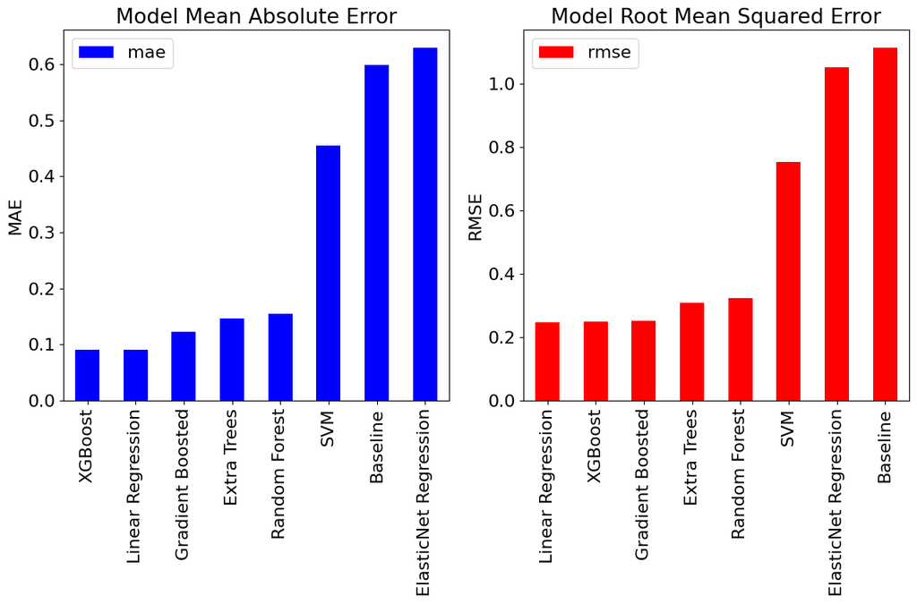

```python
from IPython.core.pylabtools import figsize
figsize(12, 8)
plt.rcParams['font.size'] = 16
# Root mean squared error
ax =  plt.subplot(1, 2, 1)
results.sort_values('mae', ascending = True).plot.bar(y = 'mae', color = 'b', ax = ax)
plt.title('Model Mean Absolute Error'); plt.ylabel('MAE');

# Median absolute percentage error
ax = plt.subplot(1, 2, 2)
results.sort_values('rmse', ascending = True).plot.bar(y = 'rmse', color = 'r', ax = ax)
plt.title('Model Root Mean Squared Error'); plt.ylabel('RMSE');

plt.tight_layout()
```

```python
results
```

|  | mae | rmse |
| --- | --- | --- |
| Linear Regression | 0.090551 | 0.247004 |
| ElasticNet Regression | 0.629783 | 1.050794 |
| Random Forest | 0.154367 | 0.3231 |
| Extra Trees | 0.146545 | 0.308016 |
| SVM | 0.454641 | 0.752122 |
| Gradient Boosted | 0.122851 | 0.250963 |
| XGBoost | 0.090472 | 0.249603 |
| Baseline | 0.598817 | 1.112821 |

```
>lr 0.982 (0.009)
>en 0.017 (0.003)
>rf 0.989 (0.005)
>SVM 0.961 (0.009)
>Extra Trees 0.989 (0.005)
>Gradient Boost 0.970 (0.007)
>XGBoost 0.981 (0.008)
```

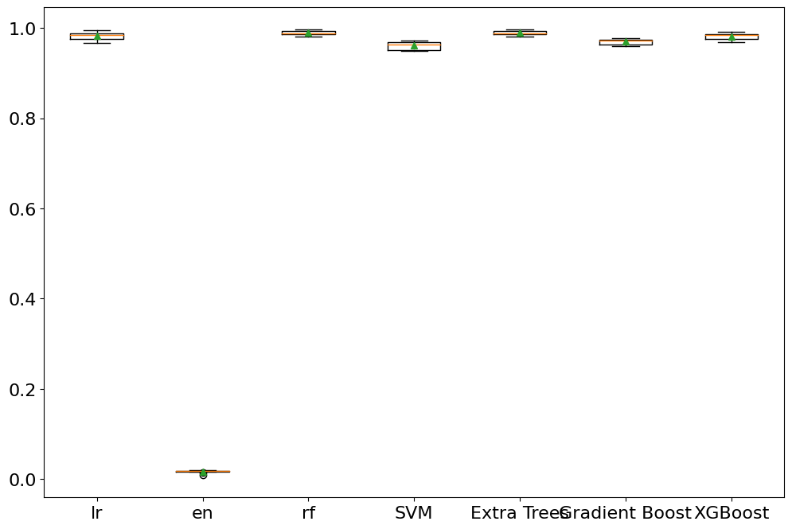

```python
from numpy import mean
from numpy import std
from sklearn.model_selection import cross_val_score
from sklearn.model_selection import KFold
from matplotlib import pyplot
def get_models():
  models = dict()
  models['lr'] = LinearRegression()
  models['en'] = ElasticNet(alpha=1.0, l1_ratio=0.5)
  models['rf'] = RandomForestRegressor(n_estimators=50)
  models['SVM']= SVR(kernel='rbf', degree=3, C=1.0, gamma='auto')
  models['Extra Trees'] = ExtraTreesRegressor(n_estimators=50)
  models['Gradient Boost'] = GradientBoostingRegressor(n_estimators=20)
  models['XGBoost'] = xgb.XGBRegressor(base_score=0.5,
                          booster='gbtree',
                          n_estimators=350,
                          objective='reg:squarederror',
                          max_depth=3,
                          learning_rate=0.01)
  return models

# evaluate a given model using cross-validation
def evaluate_model(model, X, y):
	cv = KFold(n_splits=10, shuffle=True, random_state=42)
	scores = cross_val_score(model, X, y, scoring='r2', cv=cv, n_jobs=-1, error_score='raise')
	return scores


# get the models to evaluate
models = get_models()
# evaluate the models and store results
results, names = list(), list()
for name, model in models.items():
	scores = evaluate_model(model, X_train_hour, y_train_hour_transformed)
	results.append(scores)
	names.append(name)
	print('>%s %.3f (%.3f)' % (name, mean(scores), std(scores)))
# plot model performance for comparison
pyplot.boxplot(results, labels=names, showmeans=True)
pyplot.show()
```

```
>lr -0.015 (0.002)
>en -0.214 (0.013)
>rf -0.010 (0.001)
>SVM -0.081 (0.002)
>Extra Trees -0.010 (0.001)
>Gradient Boost -0.032 (0.002)
>XGBoost -0.028 (0.002)
```

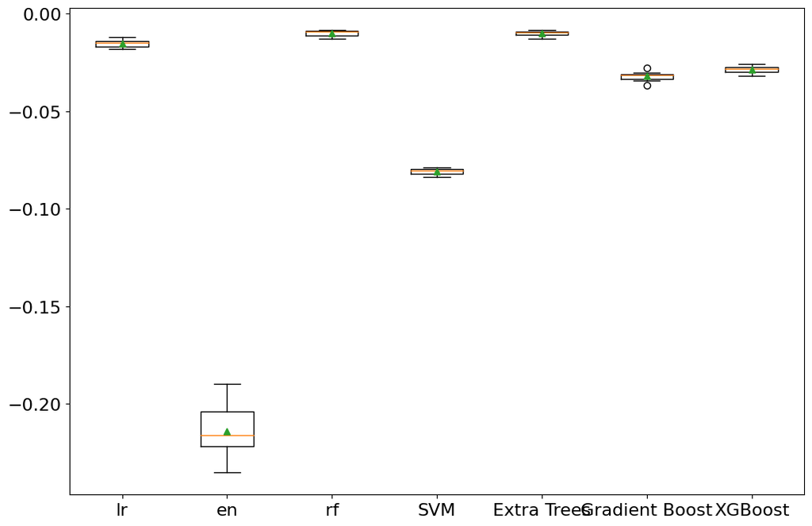

```python
def get_models():
  models = dict()
  models['lr'] = LinearRegression()
  models['en'] = ElasticNet(alpha=1.0, l1_ratio=0.5)
  models['rf'] = RandomForestRegressor(n_estimators=50)
  models['SVM']= SVR(kernel='rbf', degree=3, C=1.0, gamma='auto')
  models['Extra Trees'] = ExtraTreesRegressor(n_estimators=50)
  models['Gradient Boost'] = GradientBoostingRegressor(n_estimators=20)
  models['XGBoost'] = xgb.XGBRegressor(base_score=0.5,
                          booster='gbtree',
                          n_estimators=350,
                          objective='reg:squarederror',
                          max_depth=3,
                          learning_rate=0.01)
  return models

# evaluate a given model using cross-validation
def evaluate_model(model, X, y):
	cv = KFold(n_splits=10, shuffle=True, random_state=42)
	scores = cross_val_score(model, X, y, scoring='neg_mean_absolute_error', cv=cv, n_jobs=-1, error_score='raise')
	return scores


# get the models to evaluate
models = get_models()
# evaluate the models and store results
results, names = list(), list()
for name, model in models.items():
	scores = evaluate_model(model, X_train_hour, y_train_hour_transformed)
	results.append(scores)
	names.append(name)
	print('>%s %.3f (%.3f)' % (name, mean(scores), std(scores)))
# plot model performance for comparison
pyplot.boxplot(results, labels=names, showmeans=True)
pyplot.show()
```

```python
if CFG.train_CV_model:
    tss = TimeSeriesSplit(n_splits=5, test_size=365, gap=1)
    train = train.sort_index()

    #lists to store data for each CV
    scores = []
    preds = []

    #train the model on 5 seperate train, eval splits to find the best parameters and observe performance
    for train_idx, eval_idx in tss.split(train):
        train_set = train.iloc[train_idx]
        eval_set = train.iloc[eval_idx]

        X_train = train_set[features_xgb_reg_hour]
        y_train = train_set[transformed_target]
        X_eval = eval_set[features_xgb_reg_hour]
        y_eval = eval_set[transformed_target]

        #define the model
        xgb_reg = xgb.XGBRegressor(n_estimators=1000,
                                   max_depth=4, booster='gbtree',
                                   early_stopping_rounds=50, base_score=0.5,
                                   objective='reg:squarederror', learning_rate=0.01)

        #train the model
        xgb_reg.fit(X_train, y_train,
                    eval_set = [(X_train, y_train), (X_eval, y_eval)],
                    verbose=100)

        y_pred = xgb_reg.predict(X_eval)
        preds.append(y_pred)
        score = mean_absolute_percentage_error(y_eval, y_pred)
        scores.append(score)
```

```python
CFG.train_model = True
if CFG.train_model:
    #train on all training data
    X_train_all = train[features_xgb_reg_hour]
    y_train_all = train[transformed_target]

    xgb_reg = xgb.XGBRegressor(base_score=0.5,
                          booster='gbtree',
                          n_estimators=350,
                          objective='reg:squarederror',
                          max_depth=3,
                          learning_rate=0.01)

    xgb_reg.fit(X_train_all, y_train_all,
           eval_set=[(X_train_all, y_train_all)],
           verbose=100)
```

```python
CFG.train_model = True
if CFG.train_model:
    #train on all training data
    X_train_all = train[features_xgb_reg_hour]
    y_train_all = train[transformed_target]

    et_reg = ExtraTreesRegressor(n_estimators=50)

    et_reg.fit(X_train_all, y_train_all)
```

```python
X_test = test[features_xgb_reg_hour]
y_test = test[transformed_target]
test['xgb_predictions'] = xgb_reg.predict(X_test)
```

```python
test['et_predictions'] = et_reg.predict(X_test)
```

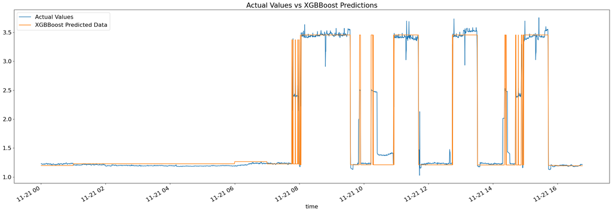

```python
if CFG.plot_graphs:
    ax = y_test.plot(figsize=(30,10))
    test['xgb_predictions'].plot(ax=ax)
    plt.legend(['Actual Values', 'XGBBoost Predicted Data'])
    plt.title("Actual Values vs XGBBoost Predictions")
    plt.show()
```

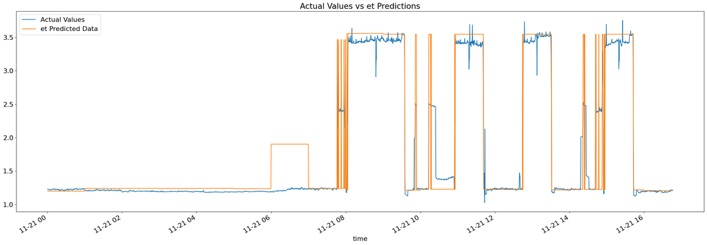

```python
if CFG.plot_graphs:
    ax = y_test.plot(figsize=(30,10))
    test['et_predictions'].plot(ax=ax)
    plt.legend(['Actual Values', 'et Predicted Data'])
    plt.title("Actual Values vs et Predictions")
    plt.show()
```

```python
y_train_pred = xgb_reg.predict(X_train_all)
score_train = mean_absolute_percentage_error(y_train_all, y_train_pred)
print(f'MAPE Score on train set: {score_train:0.2f}')
```

```
MAPE Score on train set: 1.90
```

```python
score_test = mean_absolute_percentage_error(y_test, test['xgb_predictions'])
print(f'MAPE Score on test set: {score_test:0.2f}')
```

```
MAPE Score on test set: 4.63
```

```python
model_name.append("XGBoost Model")
training_scores.append(score_train)
testing_scores.append(score_test)
```

```python
y_train_pred = et_reg.predict(X_train_all)
score_train = mean_absolute_percentage_error(y_train_all, y_train_pred)
print(f'Et MAPE Score on train set: {score_train:0.2f}')
```

```
Et MAPE Score on train set: 0.58
```

```python
score_test = mean_absolute_percentage_error(y_test, test['et_predictions'])
print(f'ET MAPE Score on test set: {score_test:0.2f}')
```

```
ET MAPE Score on test set: 8.36
```

```python
model_name.append("ET Model")
training_scores.append(score_train)
testing_scores.append(score_test)
```

```python
model_scores = pd.DataFrame({'Model Names' : model_name, 'Training Scores' : training_scores, 'Testing Scores' : testing_scores})
model_scores = model_scores.set_index('Model Names')
model_scores
```

| Model Names | Training Scores | Testing Scores |
| --- | --- | --- |
| Linear Regression Model with hour x variable | 1.636133 | 8.545395 |
| Linear Regression Model without hour as x variable | 0.000000 | 8.307741 |
| Transformed Linear Regression Model with hour x variable | 0.948260 | 4.639980 |
| Transformed Linear Regression Model without hour as x variable | 209.260015 | 4.547847 |
| XGBoost Model | 1.898350 | 4.626369 |
| ET Model | 0.575077 | 8.363954 |

# Conclusion

## Save and Export Model

```python
if CFG.train_complete_model:
    xgb_reg.save_model('amp_cosumption_prediction_model.json')
else:
    xgb_reg = xgb.XGBRegressor()
    xgb_reg.load_model('amp_cosumption_prediction_model.json')
```

```python
xgb_reg = xgb.XGBRegressor()
xgb_reg.load_model('amp_cosumption_prediction_model.json')
```

# Learned Feature Importance

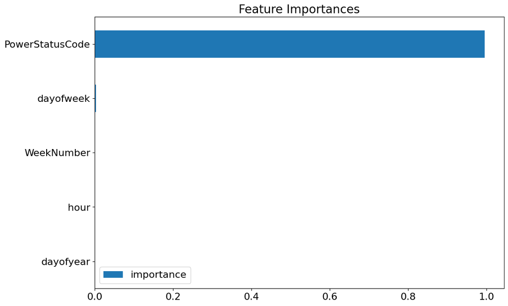

```python
feat_imp = pd.DataFrame(data=xgb_reg.feature_importances_,
                        index = xgb_reg.feature_names_in_,
                        columns=['importance'])
feat_imp.sort_values('importance').plot(kind = 'barh')
plt.title("Feature Importances")
plt.show()
```

## Future Prediction

```python
future = pd.date_range('2023-11-22', '2023-11-25', freq='1h')
future_df = pd.DataFrame(index=future)
future_df['PowerStatusCode'] = 0
for i in future_df.index.day:
  if i ==22:
    future_df['PowerStatusCode'].loc[future_df.index.day==i]=0
  if i ==23:
    future_df['PowerStatusCode'].loc[future_df.index.day==i]=1
  if i ==24:
    future_df['PowerStatusCode'].loc[future_df.index.day==i]=0
  if i ==25:
    future_df['PowerStatusCode'].loc[future_df.index.day==i]=0
```

```python
features_xgb_reg_hour.insert(len(features_xgb_reg_hour),'isFuture')
```

```python
def create_time_series_features(df):
    """
    Creates time series based feature based on datetime index
    """
    df = df.copy()
    df['PowerStatusCode'] = df.PowerStatusCode
    df['date'] = df.index
    df['WeekNumber'] = df['date'].dt.isocalendar().week
    df['hour'] = df.index.hour
    df['dayofweek'] = df.index.dayofweek
    df['year'] = df.index.year
    df['dayofyear'] = df.index.dayofyear
    df['quarter'] = df.index.quarter
    df['dayofmonth'] = df['date'].dt.day
    df['date_offset'] = (df.date.dt.month*100 + df.date.dt.day - 320)%1300
    df['season'] = pd.cut(df['date_offset'], [-1, 300, 602, 900, 1301],
                         labels=['Spring', 'Summer', 'Fall', 'Winter'])
    return df
```

```python
future_df['isFuture']=True
df['isFuture']=False
future_df = create_time_series_features(future_df)
future_df = pd.get_dummies(future_df)
#future_df.WeekNumber = future_df.WeekNumber.astype(int)
df_final = pd.concat([df[features_xgb_reg_hour], future_df[features_xgb_reg_hour]])
```

```python
future_df_with_features = df_final.query('isFuture').copy()
```

```python
future_df_with_features['predictions'] = xgb_reg.predict(future_df_with_features[['WeekNumber', 'hour', 'dayofweek', 'dayofyear', 'PowerStatusCode']])
```

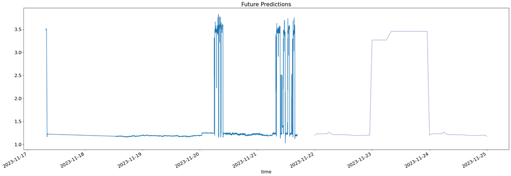

```python
fig, ax = plt.subplots(figsize=(30, 10))
#future_df_with_features['predictions'].plot(ax=ax, color=color_pal[4], lw=1, ms=1)
df['TransformedTotalCurrentAmperage'].plot(ax=ax)
future_df_with_features['predictions'].plot(ax=ax, color=color_pal[4], lw=1, ms=1)
plt.title("Future Predictions")
plt.show()
```

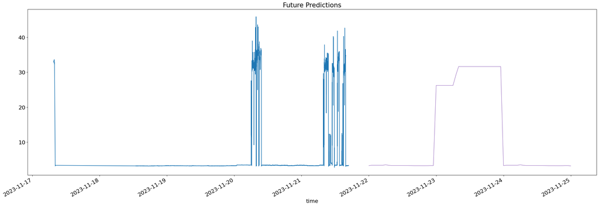

```python
fig, ax = plt.subplots(figsize=(30, 10))
#future_df_with_features['predictions'].plot(ax=ax, color=color_pal[4], lw=1, ms=1)
df['TotalCurrentAmperage'].plot(ax=ax)
np.exp(future_df_with_features['predictions']).plot(ax=ax, color=color_pal[4], lw=1, ms=1)
plt.title("Future Predictions")
plt.show()
```

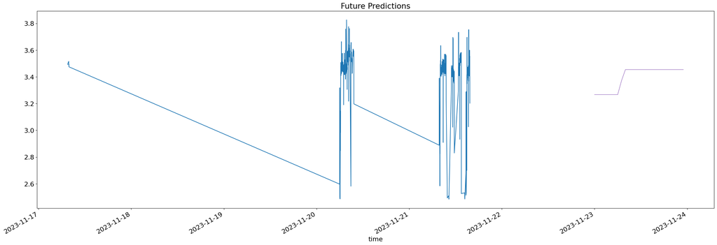

```python
fig, ax = plt.subplots(figsize=(30, 10))
#future_df_with_features['predictions'].plot(ax=ax, color=color_pal[4], lw=1, ms=1)
df['TransformedTotalCurrentAmperage'][df['PowerStatusCode']==1].plot(ax=ax)
future_df_with_features['predictions'][future_df_with_features['PowerStatusCode']==1].plot(ax=ax, color=color_pal[4], lw=1, ms=1)
plt.title("Future Predictions")
plt.show()
```

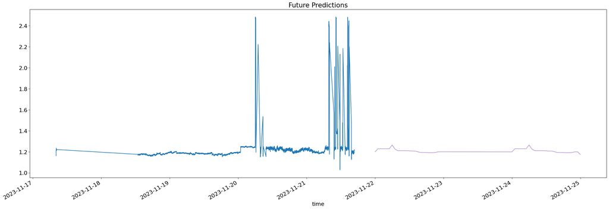

```python
fig, ax = plt.subplots(figsize=(30, 10))
#future_df_with_features['predictions'].plot(ax=ax, color=color_pal[4], lw=1, ms=1)
df['TransformedTotalCurrentAmperage'][df['PowerStatusCode']==0].plot(ax=ax)
future_df_with_features['predictions'][future_df_with_features['PowerStatusCode']==0].plot(ax=ax, color=color_pal[4], lw=1, ms=1)
plt.title("Future Predictions")
plt.show()
```

# Final Coclusion

# Working Proof of concept

- I have created a small proof of concept for the time series prediction model, with the model traind and saved. The POC is also shared with this report.

```python
!jupyter-nbconvert --to html /content/drive/MyDrive/Colab_Notebooks/Time_Series_Power_Consumption_Analysis.ipynb
```